# Theoretical Ecology (EEMB 595TE) Spring 2018 Class 4: Random effects & State-space models

[figure not shown]

## Update the course material for this week

**As you walk in today try Exercise1.R in the folder**

To update the course repository on your computer, you will `pull` a current copy of the repository. To do this:

1. Open your terminal/bash.
2. Navigate to the course repository. If this is in your root directory then type:

   ```bash
   cd
   cd EEMB595TE
   ```

3. Paste the following into the terminal/bash:

   ```bash
   git pull
   ```

## Last weeks objectives

1. To understand the purpose of statistical models
2. To have a solid practical understanding of a generalized linear model
   - What is a design matrix?
   - What is a link function?
   - How do you chose a statistical distribution for an observed response?

## This weeks objectives

1. To learn the general principles of what occurs mathematically when you indicate a random effect
2. To learn how to create a state-space model

### Course schedule

| Week | Date | Subject | Book.chapters |
| --- | --- | --- | --- |
| 1 | 5-Apr | Course outline & Github | — |
| 2 | 12-Apr | Bayesian vs. Frequentist | Chpt 1,2 |
| 3 | 19-Apr | GLM in R and JAGS | Chpt 3 |
| 4 | 26-Apr | Random effects & State-space models | Chpt 4, 5 |
| 5 | 3-May | Analyzing mark-recapture data (CJS models) | Chpt 7,9 |
| 6 | 10-May | Analyzing mark-recapture data (JS models) | Chpt 10 |
| 7 | 17-May | Occupancy & N-mixture models | Chpt 13 |
| 8 | 24-May | Student presentations | — |
| 9 | 31-May | Student presentations | — |
| 10 | 7-Jun | Student presentations | — |

## Review expectations for presentations

*Either:*

- Pick a topic we did not cover in class and teach your peers how to use this method-
- Analyze a dataset in a way we learned in class and present the results to your peers
- Analyze a dataset in a way we did not learn in class and present the results to your peers

*Expectations:*

- For a single person presenting, the time allotted is: 10 minutes
- For each additional person in the group add 10 minutes.
- You can use a combination of powerpoint and R script or a Rmarkdown file
  - You MUST present code to the class
- Your analysis/project does *NOT* have to deal with population ecology
  - You can analyze data on fisheries, economic growth patterns, social networks, etc.
  - The goal of the project is to help you become familiar with and impliment Bayesian statistics
  - We want to provide a safe space for you to present ideas, talk about your work, and recieve constructive feedback from your peers
- All project materials are due at the beginning of class on May 24th, even if you don’t present until June 7th

*Question:* How many groups/people do we have presenting?

- One person per group should raise their hand
- I will email an excel sheet after class to have a written copy of the groups and tentative project titles

## Reviewing the parts to a Bayesian model

```r
# 1. Simulate the code
# Open the library
library("jagsUI")
```

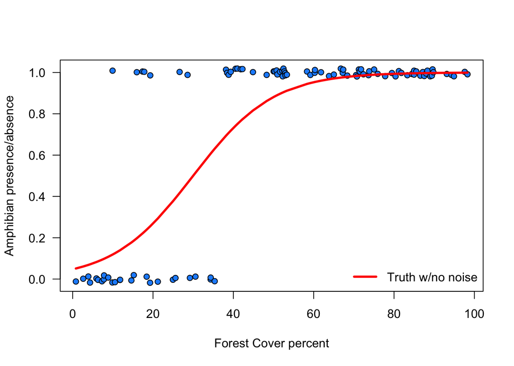

```r
# Simulate the data
nSites <- 100

# Parameters
alpha <- -3
beta <- 0.1

# Covariate- Percent forest cover
Forest_cover <- runif(nSites, min = 0, max = 100)

Forest_cover <- Forest_cover[order(Forest_cover)]

p <- plogis(alpha + beta * Forest_cover)

z <- rbinom(nSites, 1, p = p)

# Visulaize the data
plot(Forest_cover, jitter(z, 0.1), ylab = "Amphibian presence/absence", xlab = "Forest Cover percent", las= 1, pch = 21, col = "black", bg = "dodgerblue")

lines(Forest_cover, p, col = "red", lwd = 3)

legend("bottomright", "Truth w/no noise", lty = 1, lwd = 3, col = "red", bty = "n")
```

```r
# 2. Write the model in the JAGS language
{
sink("model.txt")
cat("
model{

#--- Priors

alpha ~ dnorm(0, 0.001)
beta ~ dnorm(0, 0.001)

# Ecological model

for(i in 1:nSites){
  z[i] ~ dbern(p[i])
    logit(p[i]) = alpha + beta * Forest_cover[i]
}

}
", fill = TRUE)
sink()
}
```

```r
# 3. Bundle data, set initial values, indicate the parameters to monitor, set MCMC settings, and then run the model

# Bundle the data
jags.data <- list(nSites = nSites,
                  z = z,
                  Forest_cover = Forest_cover)

# Initial values
inits <- function(){list(alpha = runif(1, -4, -2),
                         beta = runif(1, 0, 0.5))}

# Parameters to monitor
params <- c("alpha", "beta")

# Set MCMC settings
ni <- 10000
nb <- 1000
nt <- 10
nc <- 3

# Run the model
out <- jags(data = jags.data, inits = inits, parameters.to.save = params, model.file = "model.txt", n.chains = nc, n.thin = nt, n.iter = ni, n.burnin = nb, parallel = TRUE)
```

```
##
## Processing function input.......
##
## Done.
##
## Beginning parallel processing using 3 cores. Console output will be suppressed.
##
## Parallel processing completed.
##
## Calculating statistics.......
##
## Done.
```

```r
# 4. Compare model output to the truth
data.frame(parameters = c("alpha", "beta"), truth = c(alpha, beta), model_output = c(out$mean$alpha, out$mean$beta))
```

```
##   parameters truth model_output
## 1      alpha  -3.0   -3.7603540
## 2       beta   0.1    0.1420239
```

## Random effects models

- An important extension of the generalized linear model (GLM)
- Known as a generalized linear mixed model (GLMM)
- What are random effects?
- The are two or more parameters or effects that “belong together” in some way
  - Simply implying a grouping effect for a set of parameters
  - We can set intercepts or slopes are random effects (suggesting that the collection of intercepts or slopes belong to a common distributon)
- A common stochasistic process has generated the effects
  - For example, time, space, species identity, etc.
- We link groups in random effects usng a distribution- which itself has is goverend by parameters (known as hyperpriors)
- We are free to chose an effect as random or fixed
- A GLMM is a hierarchical model wuth one level
- Random effects can be continous or discrete variables

When to use a random effect: Ask yourself the question - “Are my groups completely independent or can we regard them as being part of a large population?”

Fixed effects are completely independent

Random effects are not independent

```
- Regard them as a samples froma larger number of effects, and we want to learn something about the population effect
```

- Pros to using random effects (pg. 78-83):
- Scope of inference- extends beyong the particular levels of a factor in the study
- Assessment of variability- we can assess the level of variability at the population level (using the standard deviation hyperprior) or we can assess the level of variation among the observed levels in the study.
- Partitioning of variability- code for unstructured variability among the units in a group- used to quantify the variability in some process (e.g., survival over time)
- Modeling of Correlations among parameters: We can assess the level of correlation between random effects. For example, model the correlation between intercept and slope or between pairs of annual values of survial and fecundity
- Avoiding Pseudoreplication- accounts for inherent structure in the data

And many more listed

- Cons to using random effects:
- Need at least 3 factors to categorize a variable as random
- Computationally expensive- need to run longer chains (i.e., more iterations), model may be more difficult to converege
- Not explained well sometimes in statistics class- challenging for many people
  - But random effects become more transparent when you are (forced) to write out the model

## A simple random effects model

We gave 3 snake populations and we have the length and mass measurements for them.

In this example:

```
- Our response variable (y) = mass

- Our explanatory variable (x) = length

- Our random effect is population- because we are taking repeated measurements from the same population
```

### 1. Simulate the data

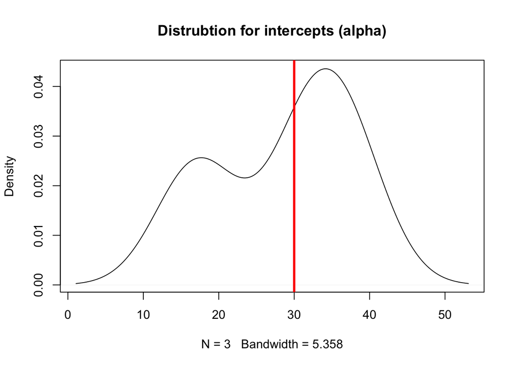

```r
# Define categorical variable = Population
Population <- as.factor(rep(c(1, 2, 3), each = 30))

# Define categorical variable = x
length <- runif(90, 1, 20)

# Define response variable = y
mu <- 30
sd <- 10
alpha <- rnorm(3, mean = mu, sd = sd)
beta <- 2
sigma <- 1

# Visualize the distribituon that alpha is coming from

plot(density(alpha), main = "Distrubtion for intercepts (alpha)")
abline(v = 30, col = "red", lwd = 3)
```

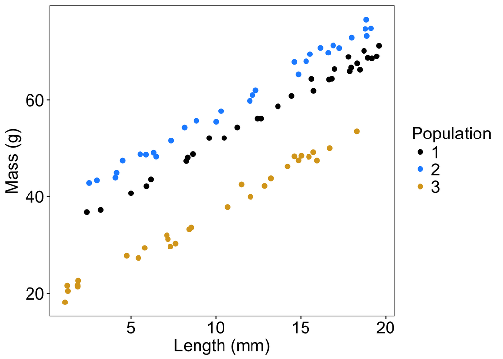

```r
## Simulate the data

mass <- numeric(length(Population))

for(i in 1:length(Population)){
  truth <- alpha[as.numeric(Population[i])] + beta * length[i]
  mass[i] <- rnorm(1, mean = truth, sd = sigma)
}


# Plot the data

library(ggplot2)
ggplot() + geom_point(aes(y = mass, x = length, col = Population), size = 2)+
  scale_color_manual(values = c("black", "dodgerblue", "goldenrod"))+
  ylab("Mass (g)")+
  xlab("Length (mm)")+
  theme_bw()+
    theme(axis.text.x = element_text(size = 17, color = "black"),
        axis.text.y = element_text(size = 17, color = "black"),
        axis.title.y = element_text(size = 17, color = "black"),
        axis.title.x =element_text(size = 17, color = "black"),
        legend.title =element_text(size = 17, color = "black"),
        legend.text =element_text(size = 17, color = "black"),
        panel.grid.major = element_blank(),
        panel.grid.minor = element_blank())
```

### 2. Define the model in the JAGS language

```r
{
sink("Random_effects.txt")
cat("
model {

# Priors
# Fixed effects
beta ~ dunif(0, 5)

# Random intercept- Retrieve a different intercept value for each population (1, 2, and 3)
for(i in 1:3){
  alpha[i] ~ dnorm(mu, tau1)
}

# Hyper-priors
# Mean estimate of normal distributon for population
mu ~ dunif(0, 50)

tau1 <- 1/ (sd * sd)
sd ~ dunif(0, 50)

tau2 <- 1/ (sigma * sigma)
sigma ~ dunif(0, 10)

# Likelihood: Note key components of a GLM on one line each
for (i in 1:n){

   mass[i] ~ dnorm(mu2[i], tau2)
      # 1. Distribution for random part

   mu2[i] <- alpha[Population[i]] + beta * length[i]
          # 2. Link function & linear predictor

   } #i
}
",fill = TRUE)
sink()
}
```

```r
# Bundle the data
Population <- as.numeric(Population)
jags.data <- list(mass = mass,
                  length = length,
                  Population = Population,
                  n = length(mass)
)

# Initial values
inits <- function() list(alpha = runif(3, 10, 30),
                         beta = runif(1, 0, 3),
                         sd = runif(1, 0, 30),
                         sigma = runif(1, 0, 5),
                         mu = runif(1, 10, 30))

# Parameters monitored
# Save
params <- c("alpha", "beta", "sigma", "sd")

# MCMC settings
ni <- 2000   # Number of iterations
nt <- 2      # Number to thin by # Useful to save disk space
nb <- 1000   # Burinin: Number of iterations to discard at the beginning
nc <- 3      # Number of chains
```

```r
# Call JAGS from R
library(jagsUI)

out <- jags(data = jags.data, inits = inits, parameters.to.save = params, model.file = "Random_effects.txt", n.chains = nc, n.thin = nt, n.iter = ni, n.burnin = nb, parallel = TRUE)
```

```
##
## Processing function input.......
##
## Done.
##
## Beginning parallel processing using 3 cores. Console output will be suppressed.
##
## Parallel processing completed.
##
## Calculating statistics.......
##
## Done.
```

```r
print(out, dig = 3)
```

```
## JAGS output for model 'Random_effects.txt', generated by jagsUI.
## Estimates based on 3 chains of 2000 iterations,
## adaptation = 100 iterations (sufficient),
## burn-in = 1000 iterations and thin rate = 2,
## yielding 1500 total samples from the joint posterior.
```

```
## MCMC ran in parallel for 0.013 minutes at time 2018-04-26 17:47:55.
##
##             mean     sd    2.5%     50%   97.5% overlap0 f  Rhat n.eff
## alpha[1]  31.353  0.337  30.668  31.347  32.012    FALSE 1 1.004   453
## alpha[2]  37.083  0.311  36.488  37.075  37.698    FALSE 1 1.003   759
## alpha[3]  17.333  0.282  16.785  17.341  17.877    FALSE 1 1.004   465
## beta       1.992  0.021   1.950   1.992   2.031    FALSE 1 1.004   472
## sigma      1.074  0.082   0.927   1.070   1.247    FALSE 1 1.001  1500
## sd        18.548 10.297   6.276  15.476  44.269    FALSE 1 1.019   121
## deviance 266.429  3.227 262.082 265.937 274.461    FALSE 1 1.000  1500
##
## Successful convergence based on Rhat values (all < 1.1).
## Rhat is the potential scale reduction factor (at convergence, Rhat=1).
## For each parameter, n.eff is a crude measure of effective sample size.
##
## overlap0 checks if 0 falls in the parameter's 95% credible interval.
## f is the proportion of the posterior with the same sign as the mean;
## i.e., our confidence that the parameter is positive or negative.
##
## DIC info: (pD = var(deviance)/2)
## pD = 5.2 and DIC = 271.635
## DIC is an estimate of expected predictive error (lower is better).
```

### Compare truth to model output

```r
data.frame(Parameters = c("alpha1", "alpha2", "alpha3", "beta", "sd", "sigma"),
           truth = c(alpha, beta, sd, sigma),
           model_output = c(out$mean$alpha, out$mean$beta, out$mean$sd, out$mean$sigma),
           lower = c(out$q2.5$alpha, out$q2.5$beta, out$q2.5$sd, out$q2.5$sigma),
           upper = c(out$q97.5$alpha, out$q97.5$beta, out$q97.5$sd, out$q97.5$sigma))
```

```
##   Parameters    truth model_output      lower     upper
## 1     alpha1 31.47396    31.353010 30.6683037 32.012498
## 2     alpha2 37.02597    37.082618 36.4875519 37.698319
## 3     alpha3 17.14998    17.332550 16.7851581 17.876895
## 4       beta  2.00000     1.991763  1.9498925  2.031297
## 5         sd 10.00000    18.548296  6.2758685 44.268955
## 6      sigma  1.00000     1.073542  0.9266232  1.246527
```

## State-space models

Definition: A hierarichal model that decomposes an observed time series of counts or other observed responses into a process variation and an observation error component.

Observation are imperfect

```
- Typically we have data with some unknown observation error
```

Example:

The change in population size over time is a Markovian process because population size at time *t+1* only depends on population size at time *t*.

Among the simplest model for population dynamics is an exponential model:

*N*<sub>*t+*</sub> = *N*~*t* $\lambda$<sub>*t*</sub>

$\lambda$<sub>*t*</sub> = the population growth rate

*t* = the time

*N* = population abundance

State-space models allow you to deal with observation error as well as process error

*N*<sub>*t+1*</sub> = *N*~*t* $\lambda$<sub>*t*</sub>

$\lambda$<sub>*t*</sub> $\sim$ Normal($\mu$~*t*, $\sigma$<sub>$\lambda$</sub><sup>2</sup>)

We assume:

Growth rate: $\lambda$<sub>*t*</sub> are realizations of a normal random process with mean $\mu$~*t* and variance $\sigma$<sub>$\lambda$</sub><sup>2</sup>

The mean is the long-term growth rate of the population

The variance is a measure of enviornmental stochastisitiy

- Note the population size is not define in model for the first year *
- We can either specify the inital state a prior for *N*<sub>1</sub> or fix it to an observed value (making the assumption that the first count is error free)

The next set of equations maps of the true state of the process onto the observed data

*y*<sub>t</sub> = *N*<sub>t</sub> + $\epsilon$<sub>t</sub>

# 5.2. A simple model

First we simulate data in a simple context

Scenario: We are interested in ibex population dynamics. The initial population size is 30 individuals and we monitor them for 25 years. The population grows annual at 2% on average. The surveys are not perfect and we assume the variance in population counts is 20 individuals.

```r
# Define underlying parameters
n.years <- 25           # Number of years
N1 <- 30                # Initial population size
mean.lambda <- 1.02     # Mean annual population growth rate
sigma2.lambda <- 0.02   # Process (temporal) variation of the growth rate
sigma2.y <- 20          # Variance of the observation error

# Define empty vectors to hold observed data (y) and true data (N)
y <- N <- numeric(n.years)

# Fill in N[1] with the number of individuals seen the first year
N[1] <- N1

# Simulate the data under the assumption of exponential population growth
lambda <- rnorm(n.years-1, mean.lambda, sqrt(sigma2.lambda))
for (t in 1:(n.years-1)){
   N[t+1] <- N[t] * lambda[t]
   }

# Finally generate the observed data conditonal on the trye population size
for (t in 1:n.years){
   y[t] <- rnorm(1, N[t], sqrt(sigma2.y))
   }
```

Specify the model

```r
# Specify model in BUGS language
{
sink("ssm.jags")
cat("
model {
# Priors and constraints
N.est[1] ~ dunif(0, 500)            # Prior for initial population size
mean.lambda ~ dunif(0, 10)          # Prior for mean growth rate

sigma.proc ~ dunif(0, 10)           # Prior for sd of state process
sigma2.proc <- sigma.proc * sigma.proc
tau.proc <- pow(sigma.proc, -2)

sigma.obs ~ dunif(0, 100)           # Prior for sd of observation process
sigma2.obs <- sigma.obs *sigma.obs
tau.obs <- pow(sigma.obs, -2)

# Likelihood
# State process
for (t in 1:(T-1)){
   lambda[t] ~ dnorm(mean.lambda, tau.proc)
   N.est[t+1] <- N.est[t] * lambda[t]
}

# Observation process
for (t in 1:T) {
   y[t] ~ dnorm(N.est[t], tau.obs)
   }
}
",fill = TRUE)
sink()
}
```

Now bundle the data and get the information ready to be analyzed

```r
# Bundle data
jags.data <- list(y = y, T = n.years)

# Initial values
inits <- function(){list(sigma.proc = runif(1, 0, 5),
                         mean.lambda = runif(1, 0.1, 2),
                         sigma.obs = runif(1, 0, 10),
                         N.est = c(runif(1, 20, 40), rep(NA, (n.years-1))))}

# Parameters monitored
parameters <- c("lambda", "mean.lambda", "sigma2.obs", "sigma2.proc", "N.est")

# MCMC settings
ni <- 25000
nt <- 3
nb <- 10000
nc <- 3

# Call JAGS from R (BRT <1 min)
ssm <- jags(jags.data, inits, parameters, "ssm.jags", n.chains = nc, n.thin = nt, n.iter = ni, n.burnin = nb, parallel = TRUE)
```

```
##
## Processing function input.......
##
## Done.
##
## Beginning parallel processing using 3 cores. Console output will be suppressed.
##
## Parallel processing completed.
##
## Calculating statistics.......
##
## Done.
```